# MScA, Linear-Nonlinear (31010)

© Yuri Balasanov, iLykei 2016

## Week 4, Workshop 2: Analysis of HIV Protease

The data in the file **HIV_Protease.csv** show part of the analysis of HIV enzyme called Protease.  
Protease (PR) plays important role in reproductive cycle of the virus.

As the HIV-1 genome is copied within cell it is in one long string of amino acids; the PR protein cuts this string into the numerous proteins required by the HIV virus life-cycle.

Protease consists of 99 amino acids. Each amino acid can be in one of several codons.  
The active part of PR enzyme is located in positions 25, 26, 27 and are called respectively:  
25 - Aspartic acid (Asp), codons GAC, GAT;  
26 - Threonine (Thr), codons ACA, ACC, ACG, ACT;  
27 - Glycine (Gly), codons GGA, GGC, GGG, GGT.

See the image of [Protease with active aminoacids in the center (positions 25-27)](https://en.wikipedia.org/wiki/HIV-1_protease#/media/File:HIV-1_Protease_with_Active_Site.png)

Here is the sequence of 99 codons of a random patient. The corresponding codons in positions 25-27 are GAT-ACA-GGA .

```
##    [,1]      [,2]      [,3]      [,4]      [,5]      [,6]      [,7]
## V1 "CODON_1" "CODON_2" "CODON_3" "CODON_4" "CODON_5" "CODON_6" "CODON_7"
## V2 "cct"     "caa"     "atc"     "act"     "ctt"     "tgg"     "caa"
##    [,8]      [,9]      [,10]      [,11]      [,12]      [,13]
## V1 "CODON_8" "CODON_9" "CODON_10" "CODON_11" "CODON_12" "CODON_13"
## V2 "cga"     "ccc"     "ctc"      "gtc"      "cca"      "ata"
##    [,14]      [,15]      [,16]      [,17]      [,18]      [,19]
## V1 "CODON_14" "CODON_15" "CODON_16" "CODON_17" "CODON_18" "CODON_19"
## V2 "agg"      "ata"      "ggg"      "ggg"      "caa"      "cta"
##    [,20]      [,21]      [,22]      [,23]      [,24]      [,25]
## V1 "CODON_20" "CODON_21" "CODON_22" "CODON_23" "CODON_24" "CODON_25"
## V2 "aag"      "gaa"      "gcy"      "cta"      "tta"      "gat"
##    [,26]      [,27]      [,28]      [,29]      [,30]      [,31]
## V1 "CODON_26" "CODON_27" "CODON_28" "CODON_29" "CODON_30" "CODON_31"
## V2 "aca"      "gga"      "gca"      "gat"      "gat"      "aca"
##    [,32]      [,33]      [,34]      [,35]      [,36]      [,37]
## V1 "CODON_32" "CODON_33" "CODON_34" "CODON_35" "CODON_36" "CODON_37"
## V2 "gta"      "tta"      "gaa"      "gac"      "atg"      "gag"
##    [,38]      [,39]      [,40]      [,41]      [,42]      [,43]
## V1 "CODON_38" "CODON_39" "CODON_40" "CODON_41" "CODON_42" "CODON_43"
## V2 "ttg"      "cca"      "gga"      "aga"      "tgg"      "aaa"
##    [,44]      [,45]      [,46]      [,47]      [,48]      [,49]
## V1 "CODON_44" "CODON_45" "CODON_46" "CODON_47" "CODON_48" "CODON_49"
## V2 "cca"      "aaa"      "atg"      "ata"      "ggg"      "gga"
##    [,50]      [,51]      [,52]      [,53]      [,54]      [,55]
## V1 "CODON_50" "CODON_51" "CODON_52" "CODON_53" "CODON_54" "CODON_55"
## V2 "att"      "gga"      "ggt"      "ttt"      "atc"      "aaa"
##    [,56]      [,57]      [,58]      [,59]      [,60]      [,61]
## V1 "CODON_56" "CODON_57" "CODON_58" "CODON_59" "CODON_60" "CODON_61"
## V2 "gta"      "ara"      "cag"      "tat"      "gat"      "cag"
##    [,62]      [,63]      [,64]      [,65]      [,66]      [,67]
## V1 "CODON_62" "CODON_63" "CODON_64" "CODON_65" "CODON_66" "CODON_67"
## V2 "rta"      "ccc"      "ata"      "gaa"      "atc"      "tat"
##    [,68]      [,69]      [,70]      [,71]      [,72]      [,73]
## V1 "CODON_68" "CODON_69" "CODON_70" "CODON_71" "CODON_72" "CODON_73"
## V2 "gga"      "cat"      "aaa"      "gct"      "gta"      "ggt"
##    [,74]      [,75]      [,76]      [,77]      [,78]      [,79]
## V1 "CODON_74" "CODON_75" "CODON_76" "CODON_77" "CODON_78" "CODON_79"
## V2 "aca"      "gta"      "tta"      "ata"      "gga"      "cct"
##    [,80]      [,81]      [,82]      [,83]      [,84]      [,85]
## V1 "CODON_80" "CODON_81" "CODON_82" "CODON_83" "CODON_84" "CODON_85"
## V2 "aca"      "cct"      "gtc"      "aac"      "ata"      "att"
##    [,86]      [,87]      [,88]      [,89]      [,90]      [,91]
## V1 "CODON_86" "CODON_87" "CODON_88" "CODON_89" "CODON_90" "CODON_91"
## V2 "gga"      "aga"      "aat"      "ctg"      "ttg"      "act"
##    [,92]      [,93]      [,94]      [,95]      [,96]      [,97]
## V1 "CODON_92" "CODON_93" "CODON_94" "CODON_95" "CODON_96" "CODON_97"
## V2 "cag"      "ctt"      "ggt"      "tgc"      "act"      "tta"
##    [,98]      [,99]
## V1 "CODON_98" "CODON_99"
## V2 "aat"      "tty"
```

HIV-1 drugs target PR in order to disrupt their function in spreading the virus.  
The drug binds itself with the active part of PR disabling it.  
See the image of [Protease with drug binded](https://en.wikipedia.org/wiki/HIV-1_protease#/media/File:HIV_protease_1EBY.png)

Because HIV virus mutates very quickly, it develops resistance to drugs when codons in certain positions in the sequence of the enzyme get replaced by mutated versions, so that the drug does not find it.

The goal of the study in this example was to predict mutations of codons that are responsible for failure of the treatment.

Data for this example come from [Kaggle competition](https://www.kaggle.com/c/hivprogression/data).

Analyze mutations in only one position: position 2 which is amino acid Glutamine (Gln) with main codons CAA, CAG.

Read the data.

```r
HIV.Protease.Data<-read.csv(file=paste(dataPath,"HIV_Protease.csv",sep="/"),header=TRUE,sep=",")
head(HIV.Protease.Data)
```

```
##   Resp  VL CODON_2
## 1    0 4.3     caa
## 2    0 3.6     caa
## 3    0 3.2     caa
## 4    0 5.7     caa
## 5    0 3.5     caa
## 6    0 3.9     caa
```

Each row of the data corresponds to one patient. The first column shows effect of the treatment: improvement (`Resp`=1) is defined as a 100-fold decrease in the HIV-1 viral load; `Resp`=0 means resistance to drug.

The second column shows virus load, i.e. some measure of how many viruses are in the patient’s body before the treatment.

The last column shows the symbol in the second position (CODON_2) of HIV Protease which each patient has.

Show all possible expressions of CODON_2 and how many times they appear in the last column.

```r
table(HIV.Protease.Data$CODON_2)
```

```
##
## caa cag cak car maa
## 142 691   1  67   1
```

Fit logistic regression `glm.VL` using the formula `Resp~VL` with only `VL` as a predictor.

(Skipped Code)

Plot the response variable of `HIV.Protease.Data` and the fitted values of `glm.VL`

```r
head(cbind(HIV.Protease.Data$Resp,glm.VL$fitted.values))
```

```
##   [,1]       [,2]
## 1    0 0.15714185
## 2    0 0.06457383
## 3    0 0.03765410
## 4    0 0.57625950
## 5    0 0.05651215
## 6    0 0.09557494
```

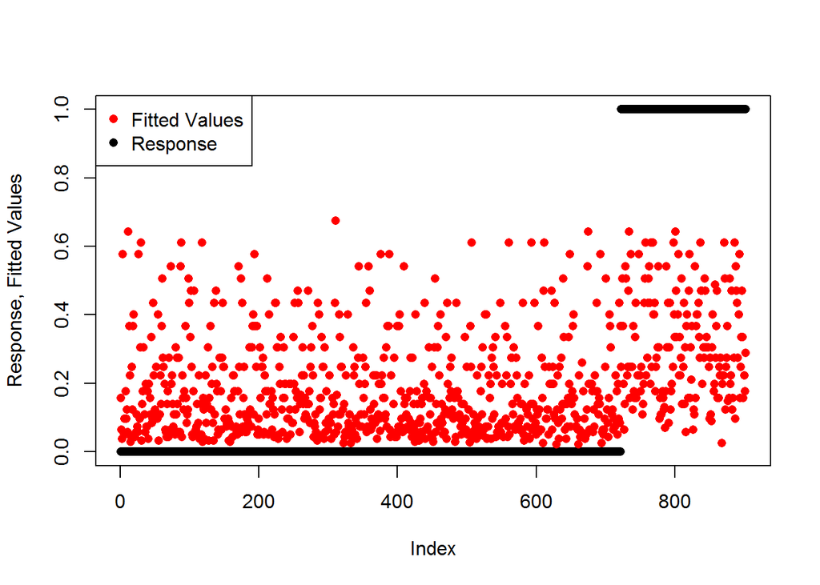

```r
matplot(1:length(HIV.Protease.Data$Resp),
        cbind(HIV.Protease.Data$Resp,glm.VL$fitted.values),pch=16,xlab="Index",ylab="Response, Fitted Values")
legend("topleft",legend=c("Fitted Values","Response"),col=c("red","black"),pch=16)
```

Interpret the plot:

**1. What do the fitted values show?**  
**2. How fitted values help predicting the response?**  
**3. Define a rule for predicting the response from this plot?**

Fit model with `CODON_2` expression as an additional predictor.  
Make this additional predictor binary: `(CODON_2=="caa")*1`.

(Skipped Code)

Compare the results of the two models.

```r
#First model
summary(glm.VL)$coefficients
```

```
##              Estimate Std. Error   z value     Pr(>|z|)
## (Intercept) -7.782844  0.6610792 -11.77294 5.381664e-32
## VL           1.419348  0.1402965  10.11677 4.655275e-24
```

```r
c(summary(glm.VL)$null.deviance,summary(glm.VL)$df.null)
```

```
## [1] 901.6158 901.0000
```

```r
#Second Model
summary(glm.VL.CODON_2)$coefficients
```

```
##                       Estimate Std. Error   z value     Pr(>|z|)
## (Intercept)          -7.932004  0.6954565 -11.40546 3.926758e-30
## VL                    1.500341  0.1485183  10.10206 5.409586e-24
## CODON_2 == "caa"TRUE -3.281612  0.7281646  -4.50669 6.584667e-06
```

```r
rbind(null=c(summary(glm.VL)$null.deviance,summary(glm.VL)$df.null,NA),
      glm.VL=c(summary(glm.VL)$deviance,summary(glm.VL)$df[2:1]),
      glm.VL.CODON_2=c(summary(glm.VL.CODON_2)$deviance,summary(glm.VL.CODON_2)$df[2:1]))
```

```
##                    [,1] [,2] [,3]
## null           901.6158  901   NA
## glm.VL         778.0680  900    2
## glm.VL.CODON_2 721.9113  899    3
```

```r
c(glm.VL=summary(glm.VL)$aic,glm.VL.CODON_2=summary(glm.VL.CODON_2)$aic)
```

```
##         glm.VL glm.VL.CODON_2
##       782.0680       727.9113
```

Plot the response and fitted values for the second model.

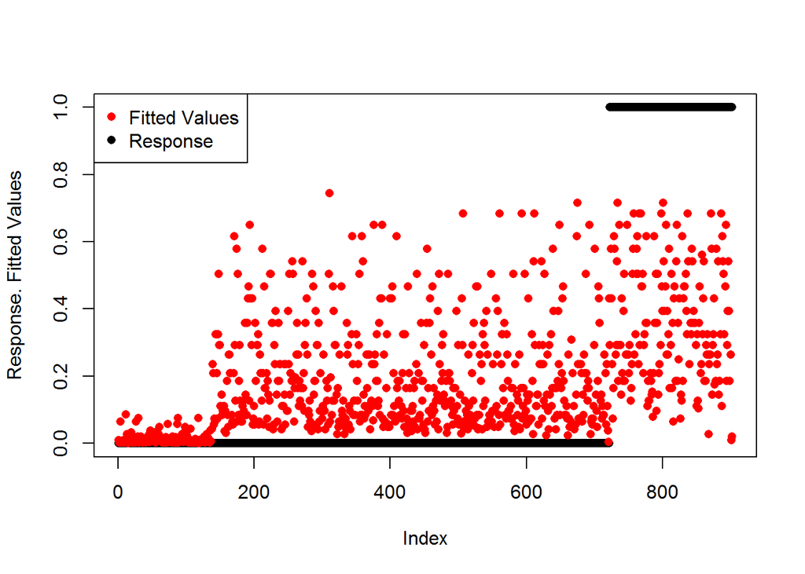

```r
matplot(1:length(HIV.Protease.Data$Resp),
        cbind(HIV.Protease.Data$Resp,glm.VL.CODON_2$fitted.values),
        pch=16,xlab="Index",ylab="Response. Fitted Values")
legend("topleft",legend=c("Fitted Values","Response"),col=c("red","black"),pch=16)
```

**Do you see an improvement? If yes, what is it?**  
**How you would predict the response using this plot?**

Compare the predictions with the response variable.

Plot predicted values together with response and interpret them.

```r
glm.VL.CODON_2.predicted<-predict(glm.VL.CODON_2,type="response")
head(glm.VL.CODON_2.predicted)
```

```
##           1           2           3           4           5           6
## 0.008474760 0.002981358 0.001638185 0.065273047 0.002567058 0.004668266
```

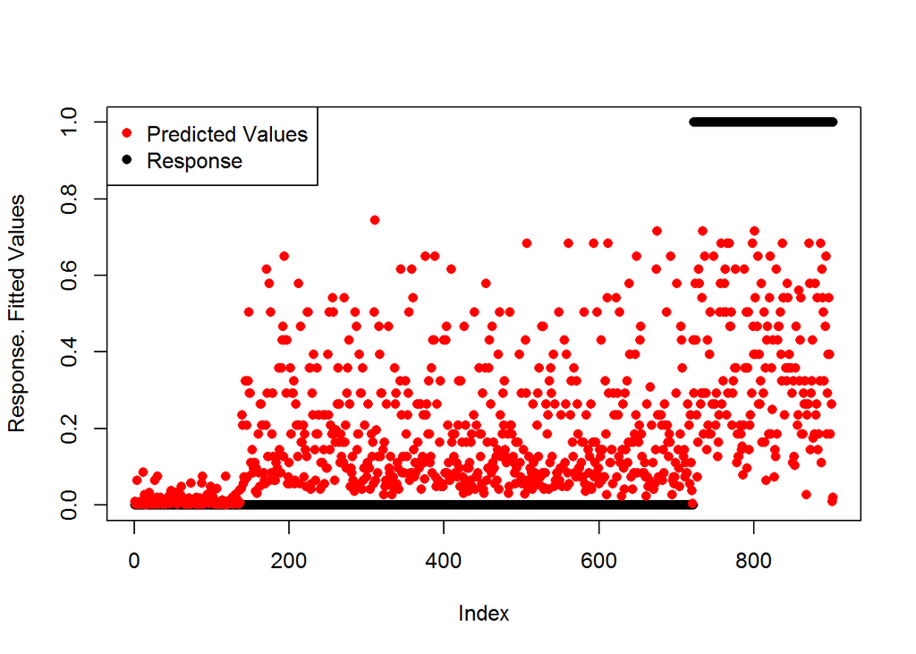

```r
matplot(1:length(HIV.Protease.Data$Resp),
        cbind(HIV.Protease.Data$Resp,glm.VL.CODON_2.predicted),pch=16,xlab="Index",ylab="Response. Fitted Values")
legend("topleft",legend=c("Predicted Values","Response"),col=c("red","black"),pch=16)
```

**What is the difference between the predicted and fitted values?**

Compare them.

```r
head(cbind(Predicted=glm.VL.CODON_2.predicted,Fitted=glm.VL.CODON_2$fitted.values))
```

```
##     Predicted      Fitted
## 1 0.008474760 0.008474760
## 2 0.002981358 0.002981358
## 3 0.001638185 0.001638185
## 4 0.065273047 0.065273047
## 5 0.002567058 0.002567058
## 6 0.004668266 0.004668266
```